# **NLP** - Natural Language Processing

#### Let’s say we have L layers, then our notation becomes:

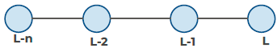

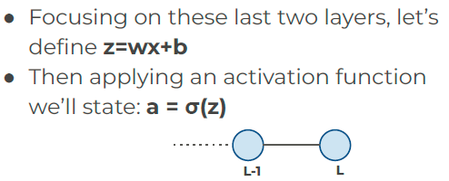

- This means we have:
  - $$z^L = w^L a^{L-1} +b^L$$

  Where $$a^{L-1}$$ is the output of the L-1 layer
  - $$a^L = σ(z^L)$$

  which is the output of the last layer
  - So the cost function is

  $$ C_0(...) =(a^L - y)^2$$

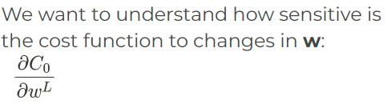

Like C depends on a which depends on z

We can decompose it like

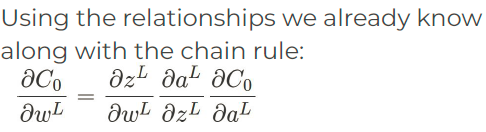

And we can do the same on biases

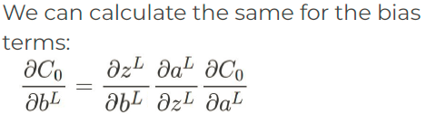

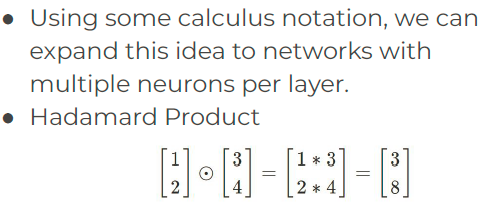

### Steps of deep learning

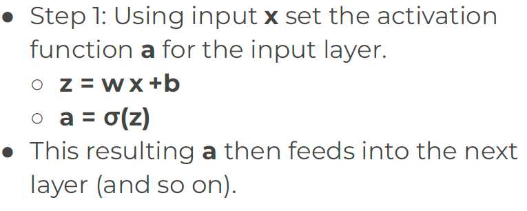

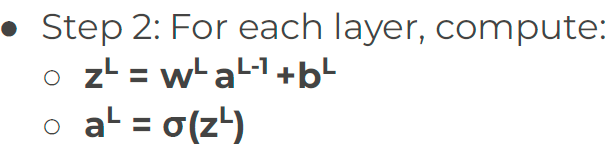

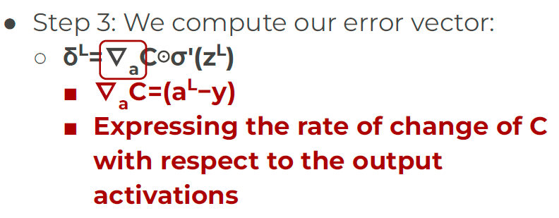

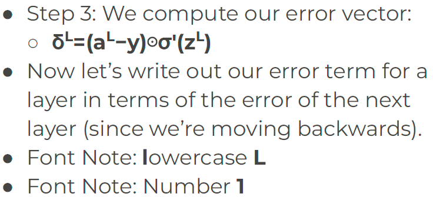

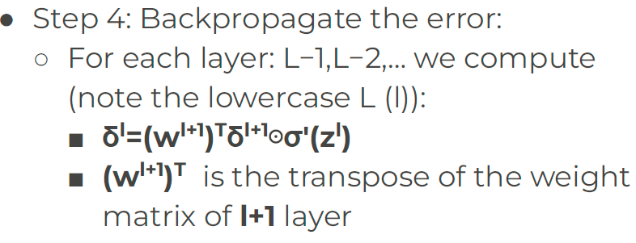

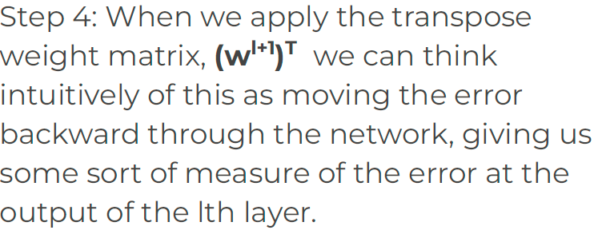

# Keras Syntax Basics

With TensorFlow 2.0 , Keras is now the main API choice. Let's work through a simple regression project to understand the basics of the Keras syntax and adding layers.

```python
import pandas as pd
df = pd.read_csv('datas/fake_reg.csv')
df.head()
```

|  | price | feature1 | feature2 |
| --- | --- | --- | --- |
| 0 | 461.527929 | 999.787558 | 999.766096 |
| 1 | 548.130011 | 998.861615 | 1001.042403 |
| 2 | 410.297162 | 1000.070267 | 998.844015 |
| 3 | 540.382220 | 999.952251 | 1000.440940 |
| 4 | 546.024553 | 1000.446011 | 1000.338531 |

```python
from sklearn.model_selection import train_test_split
# Convert Pandas to Numpy for Keras (using .values)

# Features
X = df[['feature1','feature2']].values
print("df[[feature1,feature2]].values :")
print(X)
print("\n")

# Label
y = df['price'].values
print("df[price].values: ")
print(y)
print("\n")

# Split
X_train, X_test, y_train, y_test = train_test_split(X,y,
                                                    test_size=0.3,
                                                    random_state=42)

print("X_train.shape: "+str(X_train.shape))
print("X_test.shape: "+str(X_test.shape))
```

[output not shown]

[output cut: 160 more lines]

```
 450.42484415 594.84047708 412.90687671 433.42313493 512.04979227
 478.04811801 413.29973991 415.84564074 511.58583419 472.89142434
 657.93173622 560.66409232 587.74308283 472.06766427 390.86267833
 329.06703513 526.72673086 452.10238608 413.87226234 666.44170815
 487.7692307  560.63785511 449.81047626 499.94830987 429.26772106
 508.91176483 546.20393322 621.59703226 413.84178036 449.02606966
 447.05319043 595.48648065 480.87733296 667.70856487 594.60958875
 600.04329091 508.19978205 359.19507992 365.88328071 576.73842525
 515.32519058 423.65453319 543.49227764 577.29292367 421.05894642
 625.08018462 434.27528283 657.73425067 518.35614426 481.86280607
 476.52607826 457.31318609 456.72099249 403.31557562 599.36709348]


X_train.shape: (700, 2)
X_test.shape: (300, 2)
```

```python
##################################
## Normalizing/Scaling the Data
##################################
from sklearn.preprocessing import MinMaxScaler
# help(MinMaxScaler)
scaler = MinMaxScaler()

scaler.fit(X_train)
X_train = scaler.transform(X_train)
print("X_train:")
print(X_train)
print("\n")
print("X_train.min() :"+str(X_train.min()))
print("X_train.max() :"+str(X_train.max()))
print("\n")

scaler.fit(X_test)
X_test = scaler.transform(X_test)
print("X_test:")
print(X_test)
print("\n")
print("X_test.min() :"+str(X_test.min()))
print("X_test.max() :"+str(X_test.max()))
```

```
X_train:
[[0.74046017 0.32583248]
 [0.43166001 0.2555088 ]
 [0.18468554 0.70500664]
 ...
 [0.54913363 0.79933822]
 [0.2834197  0.38818708]
 [0.56282703 0.42371827]]


X_train.min() :0.0
X_train.max() :1.0


X_test:
[[0.4510651  0.3621678 ]
 [0.64679859 0.72004419]
 [0.69079414 0.63607367]
 [0.43604055 0.71002601]
 [0.10121412 0.44056134]
 [0.56000407 0.66845651]
 [0.2431169  0.68000949]
 [0.62301913 0.39476324]
 [0.42108733 0.66979752]
 [0.63760218 0.36452454]
 [0.64401719 0.69727947]
 [0.89212721 0.45724389]
 [0.43955161 0.39556645]
 [0.38066036 0.40116125]
 [1.         0.61772683]
 [0.56847797 0.37474327]
 [0.8043091  0.41401784]
 [0.41007075 0.90091806]
 [0.56625484 0.83606247]
 [0.7202234  0.56849287]
 [0.22544856 0.31848324]
 [0.46703427 0.43578261]
 [0.3112806  0.37855161]
 [0.4413305  0.31233024]
 [0.57358456 0.63663349]
```

[output cut: 264 more lines]

```
 [0.59352895 0.45566306]
 [0.54144467 0.71592726]
 [0.30134272 0.62180931]
 [0.38273859 0.22162479]
 [0.56869738 0.61545299]
 [0.50561563 0.41801967]
 [0.42141805 0.62837406]
 [0.03524062 0.77411199]
 [0.67007521 0.681194  ]
 [0.60966185 0.31464346]
 [0.33538577 0.42563105]]


X_test.min() :0.0
X_test.max() :1.0
```

### Choosing an optimizer and loss

Keep in mind what kind of problem you are trying to solve:

```
# For a multi-class classification problem
model.compile(optimizer='rmsprop',
              loss='categorical_crossentropy',
              metrics=['accuracy'])

# For a binary classification problem
model.compile(optimizer='rmsprop',
              loss='binary_crossentropy',
              metrics=['accuracy'])

# For a mean squared error regression problem
model.compile(optimizer='rmsprop',
              loss='mse')
```

```python
##################################
## TensorFlow 2.0 Syntax
from tensorflow.keras.models import Sequential
#help(Sequential)

##################################
## Creating a Model
from tensorflow.keras.layers import Dense, Activation
#help(Dense)
#help(Activation)

##################################
## Model - adding in layers one by one
model = Sequential()

#add 1 layer with 4 units (=4 neurons)
#and activation function is Rectified Linear Unit (ReLU)
model.add(Dense(4,activation='relu'))
model.add(Dense(4,activation='relu'))
model.add(Dense(4,activation='relu'))

# Final output node for prediction
model.add(Dense(1))

model.compile(optimizer='rmsprop',loss='mse')
```

# Training

Below are some common definitions that are necessary to know and understand to correctly utilize Keras:

- Sample: one element of a dataset.
  - Example: one image is a sample in a convolutional network
  - Example: one audio file is a sample for a speech recognition model
- Batch: a set of N samples. The samples in a batch are processed independently, in parallel. If training, a batch results in only one update to the model.A batch generally approximates the distribution of the input data better than a single input. The larger the batch, the better the approximation; however, it is also true that the batch will take longer to process and will still result in only one update. For inference (evaluate/predict), it is recommended to pick a batch size that is as large as you can afford without going out of memory (since larger batches will usually result in faster evaluation/prediction).
- Epoch: an arbitrary cutoff, generally defined as "one pass over the entire dataset", used to separate training into distinct phases, which is useful for logging and periodic evaluation.
- When using validation_data or validation_split with the fit method of Keras models, evaluation will be run at the end of every epoch.
- Within Keras, there is the ability to add callbacks specifically designed to be run at the end of an epoch. Examples of these are learning rate changes and model checkpointing (saving).

```python
model.fit(X_train,y_train,epochs=250)
```

```
<keras.callbacks.History at 0x2456bcc2620>
```

[output not shown]

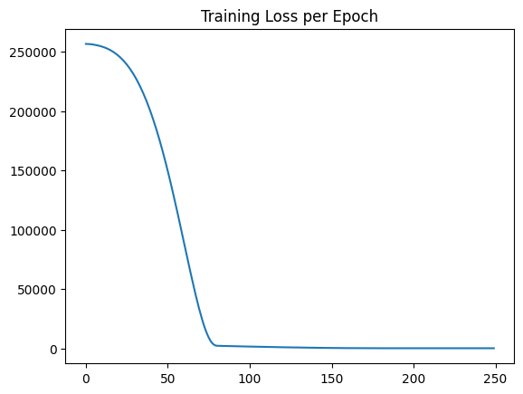

```python
##################################
## Evaluation
##################################
print("model.history.params :")
print(model.history.params)
print("\n")

print("model.history.history :")
print(model.history.history)

loss = model.history.history['loss']

sns.lineplot(x=range(len(loss)),y=loss)
plt.title("Training Loss per Epoch");
```

```python
################################################################
## Compare final evaluation (MSE) on training set and test set
################################################################

model.metrics_names

training_score = model.evaluate(X_train,y_train,verbose=0)
test_score = model.evaluate(X_test,y_test,verbose=0)

print("training_score: "+str(training_score))
print("test_score: "+str(test_score))
```

```
training_score: 26.54171371459961
test_score: 87.3015365600586
```

### Further Evaluations

```python
test_predictions = model.predict(X_test)
print("test_predictions :")
print(test_predictions)
print("\n")

pred_df = pd.DataFrame(y_test,columns=['Test Y'])
print("pred_df :")
print(pred_df)
print("\n")
```

```
test_predictions :
[[408.98352]
 [633.7646 ]
 [602.9405 ]
 [577.4373 ]
 [362.4986 ]
 [587.0842 ]
 [515.5621 ]
 [467.02362]
 [553.88806]
 [455.61636]
 [621.82294]
 [563.53094]
 [422.70245]
 [411.11646]
 [669.22894]
 [443.82404]
 [520.73834]
 [665.55835]
 [671.5372 ]
 [576.6756 ]
 [332.3769 ]
 [449.29953]
 [383.01877]
 [381.9518 ]
 [574.64874]
 [616.94415]
 [538.89996]
 [432.85632]
 [662.68536]
 [420.64502]
 [450.0102 ]
 [491.23608]
 [443.59723]
 [690.79865]
 [433.3767 ]
 [418.9376 ]
 [515.6213 ]
 [559.0617 ]
 [511.42502]
```

[output cut: 263 more lines]

```
pred_df :
         Test Y
0    402.296319
1    624.156198
2    582.455066
3    578.588606
4    371.224104
..          ...
295  525.704657
296  502.909473
297  612.727910
298  417.569725
299  410.538250

[300 rows x 1 columns]
```

```python
## CONVERT numpay array TO panda series
print(type(test_predictions))
test_predictions = pd.Series(test_predictions.reshape(300,))
print(type(test_predictions))
```

```
<class 'numpy.ndarray'>
<class 'pandas.core.series.Series'>
```

[output not shown]

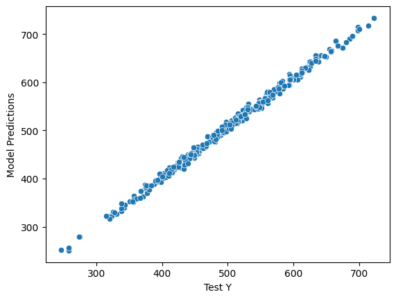

```python
pred_df = pd.concat([pred_df,test_predictions],axis=1)
pred_df.columns = ['Test Y','Model Predictions']
print(pred_df)

sns.scatterplot(x='Test Y',y='Model Predictions',data=pred_df)
```

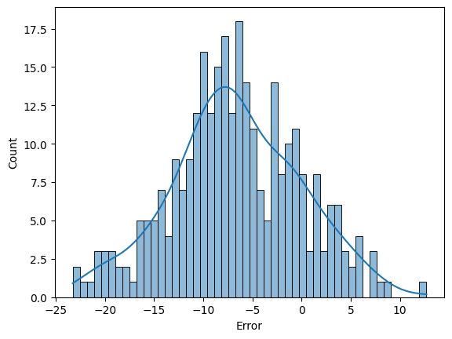

```python
pred_df['Error'] = pred_df['Test Y'] - pred_df['Model Predictions']
sns.histplot(pred_df['Error'],bins=50,kde=True)
```

```python
from sklearn.metrics import mean_absolute_error,mean_squared_error
print("mean_absolute_error :")
print(mean_absolute_error(pred_df['Test Y'],pred_df['Model Predictions']))
print("mean_squared_error :")
print(mean_squared_error(pred_df['Test Y'],pred_df['Model Predictions']))
```

```
mean_absolute_error :
7.754581572052
mean_squared_error :
87.30153166459232
```

# Predicting on brand new data

What if we just saw a brand new gemstone from the ground? What should we price it at? This is the **exact** same procedure as predicting on a new test data!

```python
# [[Feature1, Feature2]]
new_gem = [[998,1000]]

scaler.transform(new_gem)

# Don't forget to scale!
scaler.transform(new_gem)

new_gem = scaler.transform(new_gem)

model.predict(new_gem)
```

```
array([[417.62677]], dtype=float32)
```

```python
################################################################
## Saving and Loading a Model
################################################################
from tensorflow.keras.models import load_model

model.save('models\my_model.h5')

later_model = load_model('models\my_model.h5')

later_model.predict(new_gem)
```

```
array([[417.62677]], dtype=float32)
```